# Risk Factor Analysis

## Outcome Variable

**Outcome Variable:** whz

## Predictor Variables

**Intervention Variable:** enstunt

**Adjustment Set:**

unadjusted

## Stratifying Variables

The analysis was stratified on these variable(s):

- agecat
- studyid
- country

## Data Summary

| agecat | studyid | country | enstunt | n_cell | n |
| --- | --- | --- | --- | --- | --- |
| Birth | CMC-V-BCS-2002 | INDIA | 0 | 74 | 86 |
| Birth | CMC-V-BCS-2002 | INDIA | 1 | 12 | 86 |
| Birth | CMIN | BANGLADESH | 0 | 17 | 19 |
| Birth | CMIN | BANGLADESH | 1 | 2 | 19 |
| Birth | COHORTS | GUATEMALA | 0 | 732 | 756 |
| Birth | COHORTS | GUATEMALA | 1 | 24 | 756 |
| Birth | COHORTS | INDIA | 0 | 5813 | 6193 |
| Birth | COHORTS | INDIA | 1 | 380 | 6193 |
| Birth | COHORTS | PHILIPPINES | 0 | 2813 | 2899 |
| Birth | COHORTS | PHILIPPINES | 1 | 86 | 2899 |
| Birth | CONTENT | PERU | 0 | 2 | 2 |
| Birth | CONTENT | PERU | 1 | 0 | 2 |
| Birth | EE | PAKISTAN | 0 | 137 | 177 |
| Birth | EE | PAKISTAN | 1 | 40 | 177 |
| Birth | GMS-Nepal | NEPAL | 0 | 570 | 641 |
| Birth | GMS-Nepal | NEPAL | 1 | 71 | 641 |
| Birth | IRC | INDIA | 0 | 318 | 343 |
| Birth | IRC | INDIA | 1 | 25 | 343 |
| Birth | JiVitA-3 | BANGLADESH | 0 | 15027 | 18014 |
| Birth | JiVitA-3 | BANGLADESH | 1 | 2987 | 18014 |
| Birth | JiVitA-4 | BANGLADESH | 0 | 1963 | 2396 |
| Birth | JiVitA-4 | BANGLADESH | 1 | 433 | 2396 |
| Birth | Keneba | GAMBIA | 0 | 1425 | 1466 |
| Birth | Keneba | GAMBIA | 1 | 41 | 1466 |
| Birth | MAL-ED | BANGLADESH | 0 | 187 | 215 |
| Birth | MAL-ED | BANGLADESH | 1 | 28 | 215 |
| Birth | MAL-ED | BRAZIL | 0 | 56 | 62 |
| Birth | MAL-ED | BRAZIL | 1 | 6 | 62 |
| Birth | MAL-ED | INDIA | 0 | 37 | 45 |
| Birth | MAL-ED | INDIA | 1 | 8 | 45 |

[output cut: 134 more lines]

The following strata were considered:

- agecat: 24 months, studyid: CMC-V-BCS-2002, country: INDIA
- agecat: 24 months, studyid: CMIN, country: BANGLADESH
- agecat: 24 months, studyid: COHORTS, country: GUATEMALA
- agecat: 24 months, studyid: COHORTS, country: INDIA
- agecat: 24 months, studyid: COHORTS, country: PHILIPPINES
- agecat: 24 months, studyid: CONTENT, country: PERU
- agecat: 24 months, studyid: EE, country: PAKISTAN
- agecat: 24 months, studyid: GMS-Nepal, country: NEPAL
- agecat: 24 months, studyid: IRC, country: INDIA
- agecat: 24 months, studyid: JiVitA-3, country: BANGLADESH
- agecat: 24 months, studyid: JiVitA-4, country: BANGLADESH
- agecat: 24 months, studyid: Keneba, country: GAMBIA
- agecat: 24 months, studyid: LCNI-5, country: MALAWI
- agecat: 24 months, studyid: MAL-ED, country: BANGLADESH
- agecat: 24 months, studyid: MAL-ED, country: BRAZIL
- agecat: 24 months, studyid: MAL-ED, country: INDIA
- agecat: 24 months, studyid: MAL-ED, country: NEPAL
- agecat: 24 months, studyid: MAL-ED, country: PERU
- agecat: 24 months, studyid: MAL-ED, country: SOUTH AFRICA
- agecat: 24 months, studyid: MAL-ED, country: TANZANIA, UNITED REPUBLIC OF
- agecat: 24 months, studyid: NIH-Birth, country: BANGLADESH
- agecat: 24 months, studyid: NIH-Crypto, country: BANGLADESH
- agecat: 24 months, studyid: PROBIT, country: BELARUS
- agecat: 24 months, studyid: PROVIDE, country: BANGLADESH
- agecat: 24 months, studyid: TanzaniaChild2, country: TANZANIA, UNITED REPUBLIC OF
- agecat: 24 months, studyid: ZVITAMBO, country: ZIMBABWE
- agecat: 6 months, studyid: CMC-V-BCS-2002, country: INDIA
- agecat: 6 months, studyid: CMIN, country: BANGLADESH
- agecat: 6 months, studyid: COHORTS, country: GUATEMALA
- agecat: 6 months, studyid: COHORTS, country: INDIA
- agecat: 6 months, studyid: COHORTS, country: PHILIPPINES
- agecat: 6 months, studyid: CONTENT, country: PERU
- agecat: 6 months, studyid: EE, country: PAKISTAN
- agecat: 6 months, studyid: GMS-Nepal, country: NEPAL
- agecat: 6 months, studyid: Guatemala BSC, country: GUATEMALA
- agecat: 6 months, studyid: IRC, country: INDIA
- agecat: 6 months, studyid: JiVitA-3, country: BANGLADESH
- agecat: 6 months, studyid: JiVitA-4, country: BANGLADESH
- agecat: 6 months, studyid: Keneba, country: GAMBIA
- agecat: 6 months, studyid: LCNI-5, country: MALAWI
- agecat: 6 months, studyid: MAL-ED, country: BANGLADESH
- agecat: 6 months, studyid: MAL-ED, country: BRAZIL
- agecat: 6 months, studyid: MAL-ED, country: INDIA
- agecat: 6 months, studyid: MAL-ED, country: NEPAL
- agecat: 6 months, studyid: MAL-ED, country: PERU
- agecat: 6 months, studyid: MAL-ED, country: SOUTH AFRICA
- agecat: 6 months, studyid: MAL-ED, country: TANZANIA, UNITED REPUBLIC OF
- agecat: 6 months, studyid: NIH-Birth, country: BANGLADESH
- agecat: 6 months, studyid: NIH-Crypto, country: BANGLADESH
- agecat: 6 months, studyid: PROBIT, country: BELARUS
- agecat: 6 months, studyid: PROVIDE, country: BANGLADESH
- agecat: 6 months, studyid: ResPak, country: PAKISTAN
- agecat: 6 months, studyid: SAS-CompFeed, country: INDIA
- agecat: 6 months, studyid: SAS-FoodSuppl, country: INDIA
- agecat: 6 months, studyid: TanzaniaChild2, country: TANZANIA, UNITED REPUBLIC OF
- agecat: 6 months, studyid: ZVITAMBO, country: ZIMBABWE
- agecat: Birth, studyid: CMC-V-BCS-2002, country: INDIA
- agecat: Birth, studyid: CMIN, country: BANGLADESH
- agecat: Birth, studyid: COHORTS, country: GUATEMALA
- agecat: Birth, studyid: COHORTS, country: INDIA
- agecat: Birth, studyid: COHORTS, country: PHILIPPINES
- agecat: Birth, studyid: CONTENT, country: PERU
- agecat: Birth, studyid: EE, country: PAKISTAN
- agecat: Birth, studyid: GMS-Nepal, country: NEPAL
- agecat: Birth, studyid: IRC, country: INDIA
- agecat: Birth, studyid: JiVitA-3, country: BANGLADESH
- agecat: Birth, studyid: JiVitA-4, country: BANGLADESH
- agecat: Birth, studyid: Keneba, country: GAMBIA
- agecat: Birth, studyid: MAL-ED, country: BANGLADESH
- agecat: Birth, studyid: MAL-ED, country: BRAZIL
- agecat: Birth, studyid: MAL-ED, country: INDIA
- agecat: Birth, studyid: MAL-ED, country: NEPAL
- agecat: Birth, studyid: MAL-ED, country: PERU
- agecat: Birth, studyid: MAL-ED, country: SOUTH AFRICA
- agecat: Birth, studyid: MAL-ED, country: TANZANIA, UNITED REPUBLIC OF
- agecat: Birth, studyid: NIH-Birth, country: BANGLADESH
- agecat: Birth, studyid: NIH-Crypto, country: BANGLADESH
- agecat: Birth, studyid: PROBIT, country: BELARUS
- agecat: Birth, studyid: PROVIDE, country: BANGLADESH
- agecat: Birth, studyid: ResPak, country: PAKISTAN
- agecat: Birth, studyid: SAS-CompFeed, country: INDIA
- agecat: Birth, studyid: ZVITAMBO, country: ZIMBABWE

### Dropped Strata

Some strata were dropped due to rare outcomes:

- agecat: Birth, studyid: CMIN, country: BANGLADESH
- agecat: Birth, studyid: CONTENT, country: PERU
- agecat: Birth, studyid: MAL-ED, country: NEPAL
- agecat: 24 months, studyid: TanzaniaChild2, country: TANZANIA, UNITED REPUBLIC OF

## Methods Detail

We’re interested in the causal parameters $E[Y_a]$ for all values of $a \in \mathcal{A}$. These parameters represent the mean outcome if, possibly contrary to fact, we intervened to set all units to have $A=a$. Under the randomization and positivity assumptions, these are identified by the statistical parameters $\psi_a=E_W[E_{Y|A,W}(Y|A=a,W)]$. In addition, we’re interested in the mean of $Y$, $E[Y]$ under no intervention (the observed mean). We will estimate these parameters by using SuperLearner to fit the relevant likelihood factors – $E_{Y|A,W}(Y|A=a,W)$ and $p(A=a|W)$, and then updating our likelihood fit using a joint TMLE.

For unadjusted analyses ($W=\{\}$), initial likelihoods were estimated using Lrnr_glm to estimate the simple $E(Y|A)$ and Lrnr_mean to estimate $p(A)$. For adjusted analyses, a small library containing Lrnr_glmnet, Lrnr_xgboost, and Lrnr_mean was used.

Having estimated these parameters, we will then use the delta method to estimate relative risks and attributable risks relative to a prespecified baseline level of $A$.

# Results Detail

## Results Plots

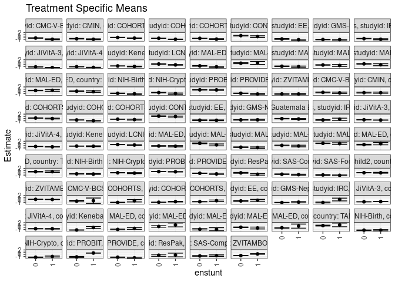

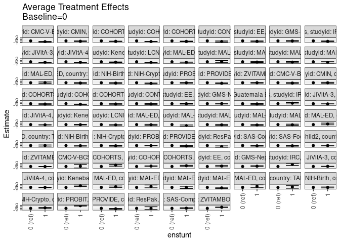

[figure not shown]

## Results Table

### Parameter: TSM

| agecat | studyid | country | intervention_level | baseline_level | estimate | ci_lower | ci_upper |
| --- | --- | --- | --- | --- | --- | --- | --- |
| Birth | CMC-V-BCS-2002 | INDIA | 0 | NA | -0.4914865 | -0.7787280 | -0.2042449 |
| Birth | CMC-V-BCS-2002 | INDIA | 1 | NA | -0.3004167 | -1.5083917 | 0.9075584 |
| Birth | COHORTS | GUATEMALA | 0 | NA | -1.0868716 | -1.1891249 | -0.9846183 |
| Birth | COHORTS | GUATEMALA | 1 | NA | -0.3079167 | -0.8560815 | 0.2402482 |
| Birth | COHORTS | INDIA | 0 | NA | -1.0012610 | -1.0317045 | -0.9708174 |
| Birth | COHORTS | INDIA | 1 | NA | -0.7321053 | -0.8664813 | -0.5977292 |
| Birth | COHORTS | PHILIPPINES | 0 | NA | -0.7565873 | -0.8033641 | -0.7098105 |
| Birth | COHORTS | PHILIPPINES | 1 | NA | -0.2893023 | -0.5922741 | 0.0136695 |
| Birth | EE | PAKISTAN | 0 | NA | -0.3968248 | -0.6042969 | -0.1893528 |
| Birth | EE | PAKISTAN | 1 | NA | -0.1157500 | -0.5386027 | 0.3071027 |
| Birth | GMS-Nepal | NEPAL | 0 | NA | -1.1368596 | -1.2290075 | -1.0447118 |
| Birth | GMS-Nepal | NEPAL | 1 | NA | -0.9525352 | -1.2284656 | -0.6766049 |
| Birth | IRC | INDIA | 0 | NA | -1.1089937 | -1.3001351 | -0.9178523 |
| Birth | IRC | INDIA | 1 | NA | 0.2412000 | -0.3840623 | 0.8664623 |
| Birth | JiVitA-3 | BANGLADESH | 0 | NA | -0.7923983 | -0.8125343 | -0.7722624 |
| Birth | JiVitA-3 | BANGLADESH | 1 | NA | -0.7045229 | -0.7450900 | -0.6639559 |
| Birth | JiVitA-4 | BANGLADESH | 0 | NA | -0.6848293 | -0.7422874 | -0.6273713 |
| Birth | JiVitA-4 | BANGLADESH | 1 | NA | -0.7058430 | -0.8275023 | -0.5841836 |
| Birth | Keneba | GAMBIA | 0 | NA | -1.2664982 | -1.3284743 | -1.2045222 |
| Birth | Keneba | GAMBIA | 1 | NA | -0.1382927 | -0.5917790 | 0.3151936 |
| Birth | MAL-ED | BANGLADESH | 0 | NA | -1.0035829 | -1.1554533 | -0.8517125 |
| Birth | MAL-ED | BANGLADESH | 1 | NA | -0.5296429 | -0.9609901 | -0.0982956 |
| Birth | MAL-ED | BRAZIL | 0 | NA | 0.3380357 | 0.0083857 | 0.6676857 |
| Birth | MAL-ED | BRAZIL | 1 | NA | 1.0083333 | 0.1448999 | 1.8717667 |
| Birth | MAL-ED | INDIA | 0 | NA | -0.9356757 | -1.2327587 | -0.6385926 |
| Birth | MAL-ED | INDIA | 1 | NA | -0.9175000 | -1.6199423 | -0.2150577 |
| Birth | MAL-ED | PERU | 0 | NA | -0.0209179 | -0.1456266 | 0.1037909 |
| Birth | MAL-ED | PERU | 1 | NA | -0.3585714 | -0.7849878 | 0.0678449 |
| Birth | MAL-ED | SOUTH AFRICA | 0 | NA | -0.2412500 | -0.4566344 | -0.0258656 |
| Birth | MAL-ED | SOUTH AFRICA | 1 | NA | 0.4887500 | -0.4348184 | 1.4123184 |

[output cut: 126 more lines]

### Parameter: E(Y)

| agecat | studyid | country | intervention_level | baseline_level | estimate | ci_lower | ci_upper |
| --- | --- | --- | --- | --- | --- | --- | --- |
| Birth | CMC-V-BCS-2002 | INDIA | NA | NA | -0.4648256 | -0.7643210 | -0.1653302 |
| Birth | COHORTS | GUATEMALA | NA | NA | -1.0621429 | -1.1631387 | -0.9611471 |
| Birth | COHORTS | INDIA | NA | NA | -0.9847457 | -1.0145305 | -0.9549609 |
| Birth | COHORTS | PHILIPPINES | NA | NA | -0.7427251 | -0.7890855 | -0.6963647 |
| Birth | EE | PAKISTAN | NA | NA | -0.3333051 | -0.5209779 | -0.1456323 |
| Birth | GMS-Nepal | NEPAL | NA | NA | -1.1164431 | -1.2040134 | -1.0288728 |
| Birth | IRC | INDIA | NA | NA | -1.0105831 | -1.1973019 | -0.8238643 |
| Birth | JiVitA-3 | BANGLADESH | NA | NA | -0.7778272 | -0.7968313 | -0.7588232 |
| Birth | JiVitA-4 | BANGLADESH | NA | NA | -0.6886269 | -0.7410452 | -0.6362086 |
| Birth | Keneba | GAMBIA | NA | NA | -1.2349454 | -1.2972413 | -1.1726496 |
| Birth | MAL-ED | BANGLADESH | NA | NA | -0.9418605 | -1.0869834 | -0.7967375 |
| Birth | MAL-ED | BRAZIL | NA | NA | 0.4029032 | 0.0896793 | 0.7161272 |
| Birth | MAL-ED | INDIA | NA | NA | -0.9324444 | -1.2067907 | -0.6580982 |
| Birth | MAL-ED | PERU | NA | NA | -0.0520175 | -0.1725298 | 0.0684947 |
| Birth | MAL-ED | SOUTH AFRICA | NA | NA | -0.1925833 | -0.4053570 | 0.0201904 |
| Birth | MAL-ED | TANZANIA, UNITED REPUBLIC OF | NA | NA | 0.7624348 | 0.5710709 | 0.9537986 |
| Birth | NIH-Birth | BANGLADESH | NA | NA | -1.3499217 | -1.4444634 | -1.2553801 |
| Birth | NIH-Crypto | BANGLADESH | NA | NA | -1.2441513 | -1.3281130 | -1.1601897 |
| Birth | PROBIT | BELARUS | NA | NA | -1.1491782 | -1.3593933 | -0.9389630 |
| Birth | PROVIDE | BANGLADESH | NA | NA | -1.2984586 | -1.3752758 | -1.2216415 |
| Birth | ResPak | PAKISTAN | NA | NA | -0.3663158 | -0.7677415 | 0.0351099 |
| Birth | SAS-CompFeed | INDIA | NA | NA | -0.6700453 | -0.8474950 | -0.4925957 |
| Birth | ZVITAMBO | ZIMBABWE | NA | NA | -0.5154897 | -0.5413479 | -0.4896314 |
| 6 months | CMC-V-BCS-2002 | INDIA | NA | NA | -0.5026766 | -0.6536848 | -0.3516685 |
| 6 months | CMIN | BANGLADESH | NA | NA | -0.5780453 | -0.7226627 | -0.4334279 |
| 6 months | COHORTS | GUATEMALA | NA | NA | 0.1940810 | 0.1226351 | 0.2655269 |
| 6 months | COHORTS | INDIA | NA | NA | -0.6908803 | -0.7184601 | -0.6633005 |
| 6 months | COHORTS | PHILIPPINES | NA | NA | -0.2938433 | -0.3352064 | -0.2524802 |
| 6 months | CONTENT | PERU | NA | NA | 1.0644279 | 0.9468682 | 1.1819876 |
| 6 months | EE | PAKISTAN | NA | NA | -0.7747022 | -0.8887874 | -0.6606170 |
| 6 months | GMS-Nepal | NEPAL | NA | NA | -0.6038416 | -0.6899448 | -0.5177384 |
| 6 months | Guatemala BSC | GUATEMALA | NA | NA | -0.0840134 | -0.1945572 | 0.0265305 |
| 6 months | IRC | INDIA | NA | NA | -0.5989297 | -0.7344491 | -0.4634104 |
| 6 months | JiVitA-3 | BANGLADESH | NA | NA | -0.5935161 | -0.6130518 | -0.5739805 |
| 6 months | JiVitA-4 | BANGLADESH | NA | NA | -0.3898055 | -0.4270507 | -0.3525603 |
| 6 months | Keneba | GAMBIA | NA | NA | -0.1846038 | -0.2354782 | -0.1337293 |
| 6 months | LCNI-5 | MALAWI | NA | NA | 0.4499404 | 0.3788501 | 0.5210308 |
| 6 months | MAL-ED | BANGLADESH | NA | NA | -0.1376763 | -0.2664642 | -0.0088885 |
| 6 months | MAL-ED | BRAZIL | NA | NA | 0.9720774 | 0.8078144 | 1.1363403 |
| 6 months | MAL-ED | INDIA | NA | NA | -0.7079979 | -0.8344175 | -0.5815783 |
| 6 months | MAL-ED | NEPAL | NA | NA | 0.1104308 | -0.0208643 | 0.2417259 |
| 6 months | MAL-ED | PERU | NA | NA | 1.0528816 | 0.9313005 | 1.1744626 |
| 6 months | MAL-ED | SOUTH AFRICA | NA | NA | 0.5421785 | 0.3900443 | 0.6943126 |
| 6 months | MAL-ED | TANZANIA, UNITED REPUBLIC OF | NA | NA | 0.5362213 | 0.4049390 | 0.6675036 |
| 6 months | NIH-Birth | BANGLADESH | NA | NA | -0.4474038 | -0.5378167 | -0.3569909 |
| 6 months | NIH-Crypto | BANGLADESH | NA | NA | 0.0297622 | -0.0491685 | 0.1086930 |
| 6 months | PROBIT | BELARUS | NA | NA | 0.5741099 | 0.5141290 | 0.6340908 |
| 6 months | PROVIDE | BANGLADESH | NA | NA | -0.1990907 | -0.2817968 | -0.1163845 |
| 6 months | ResPak | PAKISTAN | NA | NA | -0.1641841 | -0.3464247 | 0.0180565 |
| 6 months | SAS-CompFeed | INDIA | NA | NA | -0.6657084 | -0.8024377 | -0.5289791 |
| 6 months | SAS-FoodSuppl | INDIA | NA | NA | -1.0121579 | -1.1280429 | -0.8962729 |
| 6 months | TanzaniaChild2 | TANZANIA, UNITED REPUBLIC OF | NA | NA | 0.0809332 | 0.0282644 | 0.1336020 |
| 6 months | ZVITAMBO | ZIMBABWE | NA | NA | 0.3105514 | 0.2848767 | 0.3362262 |
| 24 months | CMC-V-BCS-2002 | INDIA | NA | NA | -0.5571505 | -0.6585247 | -0.4557763 |
| 24 months | CMIN | BANGLADESH | NA | NA | -0.8535391 | -0.9644236 | -0.7426546 |
| 24 months | COHORTS | GUATEMALA | NA | NA | -0.2815804 | -0.3354498 | -0.2277110 |
| 24 months | COHORTS | INDIA | NA | NA | -0.6073238 | -0.6354743 | -0.5791732 |
| 24 months | COHORTS | PHILIPPINES | NA | NA | -0.6099592 | -0.6467541 | -0.5731643 |
| 24 months | CONTENT | PERU | NA | NA | 0.5902439 | 0.4560143 | 0.7244735 |
| 24 months | EE | PAKISTAN | NA | NA | -1.0120238 | -1.1588493 | -0.8651984 |
| 24 months | GMS-Nepal | NEPAL | NA | NA | -1.1363107 | -1.2252817 | -1.0473398 |
| 24 months | IRC | INDIA | NA | NA | -0.7458150 | -0.8368180 | -0.6548120 |
| 24 months | JiVitA-3 | BANGLADESH | NA | NA | -1.2978031 | -1.3210763 | -1.2745298 |
| 24 months | JiVitA-4 | BANGLADESH | NA | NA | -1.2231088 | -1.2549632 | -1.1912543 |
| 24 months | Keneba | GAMBIA | NA | NA | -0.8099290 | -0.8570608 | -0.7627972 |
| 24 months | LCNI-5 | MALAWI | NA | NA | -0.0477709 | -0.1296526 | 0.0341109 |
| 24 months | MAL-ED | BANGLADESH | NA | NA | -0.8192925 | -0.9412667 | -0.6973182 |
| 24 months | MAL-ED | BRAZIL | NA | NA | 0.4626233 | 0.2567495 | 0.6684971 |
| 24 months | MAL-ED | INDIA | NA | NA | -0.9516520 | -1.0670654 | -0.8362385 |
| 24 months | MAL-ED | NEPAL | NA | NA | -0.3749123 | -0.4886073 | -0.2612173 |
| 24 months | MAL-ED | PERU | NA | NA | 0.1111982 | -0.0118399 | 0.2342362 |
| 24 months | MAL-ED | SOUTH AFRICA | NA | NA | 0.4090301 | 0.2879441 | 0.5301161 |
| 24 months | MAL-ED | TANZANIA, UNITED REPUBLIC OF | NA | NA | 0.0547975 | -0.0703378 | 0.1799328 |
| 24 months | NIH-Birth | BANGLADESH | NA | NA | -0.9115790 | -1.0095022 | -0.8136559 |
| 24 months | NIH-Crypto | BANGLADESH | NA | NA | -0.6103502 | -0.7050157 | -0.5156847 |
| 24 months | PROBIT | BELARUS | NA | NA | 0.6981406 | 0.5843775 | 0.8119038 |
| 24 months | PROVIDE | BANGLADESH | NA | NA | -0.8928670 | -0.9755153 | -0.8102187 |
| 24 months | ZVITAMBO | ZIMBABWE | NA | NA | -1.1825404 | -1.2814625 | -1.0836183 |

### Parameter: ATE

| agecat | studyid | country | intervention_level | baseline_level | estimate | ci_lower | ci_upper |
| --- | --- | --- | --- | --- | --- | --- | --- |
| Birth | CMC-V-BCS-2002 | INDIA | 0 | 0 | 0.0000000 | 0.0000000 | 0.0000000 |
| Birth | CMC-V-BCS-2002 | INDIA | 1 | 0 | 0.1910698 | -1.0505869 | 1.4327266 |
| Birth | COHORTS | GUATEMALA | 0 | 0 | 0.0000000 | 0.0000000 | 0.0000000 |
| Birth | COHORTS | GUATEMALA | 1 | 0 | 0.7789549 | 0.2213345 | 1.3365753 |
| Birth | COHORTS | INDIA | 0 | 0 | 0.0000000 | 0.0000000 | 0.0000000 |
| Birth | COHORTS | INDIA | 1 | 0 | 0.2691557 | 0.1313743 | 0.4069371 |
| Birth | COHORTS | PHILIPPINES | 0 | 0 | 0.0000000 | 0.0000000 | 0.0000000 |
| Birth | COHORTS | PHILIPPINES | 1 | 0 | 0.4672849 | 0.1607234 | 0.7738465 |
| Birth | EE | PAKISTAN | 0 | 0 | 0.0000000 | 0.0000000 | 0.0000000 |
| Birth | EE | PAKISTAN | 1 | 0 | 0.2810748 | -0.1899337 | 0.7520833 |
| Birth | GMS-Nepal | NEPAL | 0 | 0 | 0.0000000 | 0.0000000 | 0.0000000 |
| Birth | GMS-Nepal | NEPAL | 1 | 0 | 0.1843244 | -0.1065858 | 0.4752347 |
| Birth | IRC | INDIA | 0 | 0 | 0.0000000 | 0.0000000 | 0.0000000 |
| Birth | IRC | INDIA | 1 | 0 | 1.3501937 | 0.6963680 | 2.0040194 |
| Birth | JiVitA-3 | BANGLADESH | 0 | 0 | 0.0000000 | 0.0000000 | 0.0000000 |
| Birth | JiVitA-3 | BANGLADESH | 1 | 0 | 0.0878754 | 0.0451414 | 0.1306094 |
| Birth | JiVitA-4 | BANGLADESH | 0 | 0 | 0.0000000 | 0.0000000 | 0.0000000 |
| Birth | JiVitA-4 | BANGLADESH | 1 | 0 | -0.0210136 | -0.1543108 | 0.1122835 |
| Birth | Keneba | GAMBIA | 0 | 0 | 0.0000000 | 0.0000000 | 0.0000000 |
| Birth | Keneba | GAMBIA | 1 | 0 | 1.1282056 | 0.6705039 | 1.5859073 |
| Birth | MAL-ED | BANGLADESH | 0 | 0 | 0.0000000 | 0.0000000 | 0.0000000 |
| Birth | MAL-ED | BANGLADESH | 1 | 0 | 0.4739400 | 0.0166381 | 0.9312420 |
| Birth | MAL-ED | BRAZIL | 0 | 0 | 0.0000000 | 0.0000000 | 0.0000000 |
| Birth | MAL-ED | BRAZIL | 1 | 0 | 0.6702976 | -0.2539244 | 1.5945196 |
| Birth | MAL-ED | INDIA | 0 | 0 | 0.0000000 | 0.0000000 | 0.0000000 |
| Birth | MAL-ED | INDIA | 1 | 0 | 0.0181757 | -0.7445061 | 0.7808575 |
| Birth | MAL-ED | PERU | 0 | 0 | 0.0000000 | 0.0000000 | 0.0000000 |
| Birth | MAL-ED | PERU | 1 | 0 | -0.3376536 | -0.7819318 | 0.1066247 |
| Birth | MAL-ED | SOUTH AFRICA | 0 | 0 | 0.0000000 | 0.0000000 | 0.0000000 |
| Birth | MAL-ED | SOUTH AFRICA | 1 | 0 | 0.7300000 | -0.2183507 | 1.6783507 |

[output cut: 126 more lines]

### Parameter: PAR

| agecat | studyid | country | intervention_level | baseline_level | estimate | ci_lower | ci_upper |
| --- | --- | --- | --- | --- | --- | --- | --- |
| Birth | CMC-V-BCS-2002 | INDIA | 0 | NA | 0.0266609 | -0.1471643 | 0.2004861 |
| Birth | COHORTS | GUATEMALA | 0 | NA | 0.0247287 | 0.0045231 | 0.0449343 |
| Birth | COHORTS | INDIA | 0 | NA | 0.0165153 | 0.0079093 | 0.0251212 |
| Birth | COHORTS | PHILIPPINES | 0 | NA | 0.0138622 | 0.0043208 | 0.0234036 |
| Birth | EE | PAKISTAN | 0 | NA | 0.0635197 | -0.0443304 | 0.1713699 |
| Birth | GMS-Nepal | NEPAL | 0 | NA | 0.0204166 | -0.0121161 | 0.0529493 |
| Birth | IRC | INDIA | 0 | NA | 0.0984106 | 0.0379566 | 0.1588647 |
| Birth | JiVitA-3 | BANGLADESH | 0 | NA | 0.0145711 | 0.0074878 | 0.0216544 |
| Birth | JiVitA-4 | BANGLADESH | 0 | NA | -0.0037975 | -0.0278947 | 0.0202997 |
| Birth | Keneba | GAMBIA | 0 | NA | 0.0315528 | 0.0155969 | 0.0475087 |
| Birth | MAL-ED | BANGLADESH | 0 | NA | 0.0617224 | -0.0015515 | 0.1249964 |
| Birth | MAL-ED | BRAZIL | 0 | NA | 0.0648675 | -0.0374695 | 0.1672045 |
| Birth | MAL-ED | INDIA | 0 | NA | 0.0032312 | -0.1323722 | 0.1388347 |
| Birth | MAL-ED | PERU | 0 | NA | -0.0310997 | -0.0739461 | 0.0117467 |
| Birth | MAL-ED | SOUTH AFRICA | 0 | NA | 0.0486667 | -0.0225203 | 0.1198536 |
| Birth | MAL-ED | TANZANIA, UNITED REPUBLIC OF | 0 | NA | 0.0331211 | -0.0636852 | 0.1299273 |
| Birth | NIH-Birth | BANGLADESH | 0 | NA | -0.0035482 | -0.0401207 | 0.0330242 |
| Birth | NIH-Crypto | BANGLADESH | 0 | NA | 0.0383527 | 0.0082880 | 0.0684173 |
| Birth | PROBIT | BELARUS | 0 | NA | 0.0034378 | -0.0016094 | 0.0084851 |
| Birth | PROVIDE | BANGLADESH | 0 | NA | -0.0225523 | -0.0424967 | -0.0026080 |
| Birth | ResPak | PAKISTAN | 0 | NA | 0.0290414 | -0.2210411 | 0.2791238 |
| Birth | SAS-CompFeed | INDIA | 0 | NA | 0.0226295 | -0.0241825 | 0.0694415 |
| Birth | ZVITAMBO | ZIMBABWE | 0 | NA | 0.0396130 | 0.0318640 | 0.0473620 |
| 6 months | CMC-V-BCS-2002 | INDIA | 0 | NA | -0.0429221 | -0.1203376 | 0.0344934 |
| 6 months | CMIN | BANGLADESH | 0 | NA | -0.0070077 | -0.1230520 | 0.1090365 |
| 6 months | COHORTS | GUATEMALA | 0 | NA | -0.0378226 | -0.0703559 | -0.0052892 |
| 6 months | COHORTS | INDIA | 0 | NA | -0.0434027 | -0.0545886 | -0.0322167 |
| 6 months | COHORTS | PHILIPPINES | 0 | NA | -0.0115640 | -0.0231635 | 0.0000356 |
| 6 months | CONTENT | PERU | 0 | NA | -0.0179285 | -0.0434331 | 0.0075760 |
| 6 months | EE | PAKISTAN | 0 | NA | -0.0224853 | -0.1252240 | 0.0802534 |
| 6 months | GMS-Nepal | NEPAL | 0 | NA | 0.0059928 | -0.0320362 | 0.0440218 |
| 6 months | Guatemala BSC | GUATEMALA | 0 | NA | -0.0381362 | -0.1019447 | 0.0256724 |
| 6 months | IRC | INDIA | 0 | NA | 0.0436030 | -0.0212951 | 0.1085012 |
| 6 months | JiVitA-3 | BANGLADESH | 0 | NA | -0.0442388 | -0.0554946 | -0.0329829 |
| 6 months | JiVitA-4 | BANGLADESH | 0 | NA | -0.0434666 | -0.0668811 | -0.0200521 |
| 6 months | Keneba | GAMBIA | 0 | NA | -0.0057376 | -0.0229408 | 0.0114657 |
| 6 months | LCNI-5 | MALAWI | 0 | NA | -0.0780219 | -0.1336298 | -0.0224139 |
| 6 months | MAL-ED | BANGLADESH | 0 | NA | -0.0181301 | -0.0684999 | 0.0322396 |
| 6 months | MAL-ED | BRAZIL | 0 | NA | -0.0824018 | -0.1457182 | -0.0190854 |
| 6 months | MAL-ED | INDIA | 0 | NA | -0.0269667 | -0.0813840 | 0.0274505 |
| 6 months | MAL-ED | NEPAL | 0 | NA | -0.0313801 | -0.0796765 | 0.0169163 |
| 6 months | MAL-ED | PERU | 0 | NA | -0.0168534 | -0.0680781 | 0.0343712 |
| 6 months | MAL-ED | SOUTH AFRICA | 0 | NA | 0.0473914 | -0.0145307 | 0.1093135 |
| 6 months | MAL-ED | TANZANIA, UNITED REPUBLIC OF | 0 | NA | 0.0025034 | -0.0563055 | 0.0613123 |
| 6 months | NIH-Birth | BANGLADESH | 0 | NA | -0.0164174 | -0.0592112 | 0.0263763 |
| 6 months | NIH-Crypto | BANGLADESH | 0 | NA | -0.0240387 | -0.0585690 | 0.0104915 |
| 6 months | PROBIT | BELARUS | 0 | NA | -0.0006014 | -0.0028419 | 0.0016391 |
| 6 months | PROVIDE | BANGLADESH | 0 | NA | -0.0293090 | -0.0593638 | 0.0007459 |
| 6 months | ResPak | PAKISTAN | 0 | NA | -0.1765348 | -0.2979336 | -0.0551360 |
| 6 months | SAS-CompFeed | INDIA | 0 | NA | -0.0545268 | -0.0998749 | -0.0091787 |
| 6 months | SAS-FoodSuppl | INDIA | 0 | NA | -0.0676751 | -0.1606440 | 0.0252938 |
| 6 months | TanzaniaChild2 | TANZANIA, UNITED REPUBLIC OF | 0 | NA | -0.0022489 | -0.0167364 | 0.0122386 |
| 6 months | ZVITAMBO | ZIMBABWE | 0 | NA | -0.0063373 | -0.0152983 | 0.0026237 |
| 24 months | CMC-V-BCS-2002 | INDIA | 0 | NA | -0.1162240 | -0.1691369 | -0.0633111 |
| 24 months | CMIN | BANGLADESH | 0 | NA | -0.0887025 | -0.1766251 | -0.0007799 |
| 24 months | COHORTS | GUATEMALA | 0 | NA | -0.0941107 | -0.1316778 | -0.0565435 |
| 24 months | COHORTS | INDIA | 0 | NA | -0.0538300 | -0.0646650 | -0.0429950 |
| 24 months | COHORTS | PHILIPPINES | 0 | NA | -0.0192149 | -0.0295739 | -0.0088559 |
| 24 months | CONTENT | PERU | 0 | NA | -0.0450622 | -0.0901938 | 0.0000694 |
| 24 months | EE | PAKISTAN | 0 | NA | -0.1322238 | -0.2567114 | -0.0077362 |
| 24 months | GMS-Nepal | NEPAL | 0 | NA | -0.0067881 | -0.0446291 | 0.0310529 |
| 24 months | IRC | INDIA | 0 | NA | -0.0378774 | -0.0715838 | -0.0041710 |
| 24 months | JiVitA-3 | BANGLADESH | 0 | NA | -0.0982157 | -0.1130848 | -0.0833465 |
| 24 months | JiVitA-4 | BANGLADESH | 0 | NA | -0.0884934 | -0.1091894 | -0.0677974 |
| 24 months | Keneba | GAMBIA | 0 | NA | -0.0244269 | -0.0409652 | -0.0078886 |
| 24 months | LCNI-5 | MALAWI | 0 | NA | -0.1376613 | -0.1992234 | -0.0760991 |
| 24 months | MAL-ED | BANGLADESH | 0 | NA | -0.0652701 | -0.1115744 | -0.0189659 |
| 24 months | MAL-ED | BRAZIL | 0 | NA | 0.0140344 | -0.0648679 | 0.0929367 |
| 24 months | MAL-ED | INDIA | 0 | NA | -0.0280132 | -0.0759101 | 0.0198837 |
| 24 months | MAL-ED | NEPAL | 0 | NA | -0.0261561 | -0.0785517 | 0.0262396 |
| 24 months | MAL-ED | PERU | 0 | NA | -0.0537635 | -0.1185328 | 0.0110058 |
| 24 months | MAL-ED | SOUTH AFRICA | 0 | NA | 0.0076088 | -0.0369955 | 0.0522131 |
| 24 months | MAL-ED | TANZANIA, UNITED REPUBLIC OF | 0 | NA | -0.0289318 | -0.0874107 | 0.0295471 |
| 24 months | NIH-Birth | BANGLADESH | 0 | NA | -0.0374948 | -0.0852468 | 0.0102573 |
| 24 months | NIH-Crypto | BANGLADESH | 0 | NA | -0.0623997 | -0.1040441 | -0.0207554 |
| 24 months | PROBIT | BELARUS | 0 | NA | -0.0001240 | -0.0063756 | 0.0061275 |
| 24 months | PROVIDE | BANGLADESH | 0 | NA | -0.0362871 | -0.0640919 | -0.0084822 |
| 24 months | ZVITAMBO | ZIMBABWE | 0 | NA | -0.0068607 | -0.0623184 | 0.0485970 |